# nmf_1

Yutaka Kuroki

2018/11/5

```r
library(tidyverse)
library(lubridate)
library(dbplyr)
library(dbplot)
library(RPostgreSQL)
library(ggforce)
library(DT)
library(NMF)
library(knitr)
library(minerva)
library(GGally)
library(ggalluvial)

theme_set(theme_bw(base_family = "HiraKakuPro-W3"))
```

```r
conn <- dbConnect(PostgreSQL(),
                  host = scan("connection.txt", what = character())[1],
                  port = scan("connection.txt", what = character())[2],
                  dbname = scan("connection.txt", what = character())[3],
                  user = scan("connection.txt", what = character())[4],
                  password = scan("connection.txt", what = character())[5])

orgn <- conn %>%
  tbl(from = dbplyr::in_schema("edit", "tv_orgn_program_2"))
tmp <- conn %>%
  tbl(from = dbplyr::in_schema("processed", "tv_orgn_p_cv"))
program <- conn %>%
  tbl(from = dbplyr::in_schema("processed", "tv_program"))
ban <- conn %>%
  tbl(from = dbplyr::in_schema("processed", "bancluster_mst"))
ban1 <- conn %>%
  tbl(from = dbplyr::in_schema("sub_mst", "ban_code1_mst"))
ban2 <- conn %>%
  tbl(from = dbplyr::in_schema("sub_mst", "ban_code2_mst"))
prof_data <- conn %>%
  tbl(from = dbplyr::in_schema("processed", "profiledata"))
prof_mst <- conn %>%
  tbl(from = dbplyr::in_schema("processed", "profilemaster"))
prof <- prof_data %>%
  left_join(prof_mst, by = c("qu_genre_code", "question_code", "answer_code"))
sta <- conn %>%
  tbl(from = dbplyr::in_schema("processed", "sta_mst"))

watch_rate <- read_csv("data/processed/watch_rate.csv")

res <- read_rds("data/results_nmf.rds")
```

# 1 はじめに

テレビ視聴データを用いるにあたって

- テレビ番組を**語句**
- 視聴者を**書き手**

とみなすことによって，テキスト分析の手法や解釈が持ってこれると考えている（勝手に）  
（係り受けに由来するようなものは除く）

# 2 語句の重み

情報検査，コーパス分析，文章の自動要約などを行うとき，語句（今回の場合はテレビ番組）の重要度を示す重みが必要な場合がある． **重みの値が大きいほど，その語句（番組）が該当するテキストのキーワードになることを意味する．** 語句の重みに関する指標は多く提案されている

**ブーリアン重み付け**  
対象語句がテキストの中に現れれば1，そうでなければ0

**頻度重み付け**  
対象語句がテキストの中に現れた回数(TF: term frequency)．  
長さが異なる複数のテキストについて分析するときは長さの影響を取り除くため，テキストの長さで調整を行った調整頻度(rTF: relative term frequency)を用いることが多い（今回の分析でもそうした）． また，対数をとる場合もある

**TF-IDF重み付け**
$$\text{TF-IDF} = TF * IDF$$
で定義される．ここでIDF(inverted document frequency)は，語句がどのくらいのテキストに現れているかに関する度合いである．最もシンプルなIDFは次で定義される
$$\text{IDF}_i = {\rm log}\left(\frac{N}{df_i}\right)$$
式の中の$df_i$は対象語句$_i$を含むテキストの数，$N$はテキストの総数である．
IDFを導入するメリットは，汎用的な単語に対するフィルターである．**いくつもの文書で横断的に使われている単語はそんなに重要じゃない**という発想に由来する．

**エントロピー重み付け**  
IDFを単語（番組）がテキスト（視聴者）に現れる（視聴される）確率ととらえ，シャノンのエントロピーによる重み付けを考えることができる

# 3 テレビ視聴におけるTF-IDF

本分析では，テレビ視聴に対するTF-IDFを以下で定義する． ここで，テレビ番組のインデックスを$i=1,\dots,M$とし，視聴者のインデックスを$j=1,\dots,N$とする． また，データ期間内に視聴者$j$が番組$i$を見た視聴時間を$w_{i,j}$と表す．

$$r_j\text{TF-IDF}_{i,j} = r_j \times \text{TF}_{i,j}\times\text{IDF}_{i} =\\
\frac{1}{\sum_{i}w_{i,j}} \times w_{i,j} \times {\rm log}\left(\frac{N}{df_{i}}\right)$$

# 4 NMF（非負値行列因子分解）

NMFは得られた非負行列$Y$を以下のように二つの非負値行列$H,U$の行列積で近似する． これは$Y$を複数の基底ベクトルの適当な重み付き和で表そうとしていることに相当する．

$$Y\simeq HU$$

**非負値行列の行列積で近似することのメリット**  
NMFでは観測データの中で共起する成分をひとまとめにしたものが基底ベクトルの推定結果になる傾向がある． また，係数行列の非負性により，係数行列の要素がスパースになる傾向がある． これは観測ベクトルと近い方向を向いた基底ベクトル以外の係数はできるだけ小さくした方が良い，という直感と一致する．  
テレビ視聴がいくつかの共起パターンの加法で表されることがパターンの減算が物理的なメカニズムから想像しにくいこともメリットの一つである．

本調査では，推定には以下を用いた．

- アルゴリズム : Brunet et al.(2004)．Lee et al.(2001)の改良
- 初期値 : fastICA

Brunet et al. のアルゴリズムはKL距離に基づいた更新式を用いており，これは観測行列の各成分が独立にポアソン分布に従うを仮定した際の最尤推定に相当する．

# 5 データ概要

前節のテレビ視聴におけるTF-IDFの定義に従って番組-視聴者行列$Y$を算出した．また，その過程では以下の前処理を行った．

- program_codeが同一で番組名が異なる（特番など）は同一番組とみなした
- 行和が0になる番組，列和が0になる視聴者を除いた
- 番組名が同一でも放送時間帯が異なる（program_codeが異なる）ものは別番組とみなした

# 6 データ解析

$k$を3~9で変えながら，NMFによる分解とデータ解析を行った

## 6.1 結果概要

```r
smr <- sapply(res, function(x) summary(x)) %>%
  t() %>%
  as.data.frame()
smr %>%
  kable()
```

| rank | sparseness.basis | sparseness.coef | silhouette.coef | silhouette.basis | residuals | niter | cpu | cpu.all | nrun |
| --- | --- | --- | --- | --- | --- | --- | --- | --- | --- |
| 3 | 0.7739474 | 0.6055661 | 0.7892972 | 0.8366127 | 15789.24 | 2000 | 2279.689 | 2279.689 | 1 |
| 4 | 0.8268938 | 0.6382952 | 0.7416300 | 0.8243417 | 15089.76 | 1770 | 2135.258 | 2135.258 | 1 |
| 5 | 0.8245316 | 0.6430331 | 0.6722806 | 0.8015327 | 14592.87 | 2000 | 2759.205 | 2759.205 | 1 |
| 6 | 0.8492059 | 0.7013627 | 0.7057415 | 0.7785551 | 14230.73 | 1750 | 2576.389 | 2576.389 | 1 |
| 7 | 0.8404936 | 0.6538923 | 0.6107593 | 0.7734085 | 13991.22 | 2000 | 3301.694 | 3301.694 | 1 |
| 8 | 0.8460229 | 0.6373779 | 0.5553274 | 0.7314818 | 13582.28 | 2000 | 3470.807 | 3470.807 | 1 |
| 9 | 0.8550032 | 0.7080938 | 0.6088565 | 0.8314840 | 13363.06 | 2000 | 3855.577 | 3855.577 | 1 |

## 6.2 基底ベクトルの数について

適切な基底ベクトルの数を考察する

基底ベクトルの数と残差の関係は以下のようになっている． まだまだ線形で下がっている印象があり，まだまだやってみるべきかも

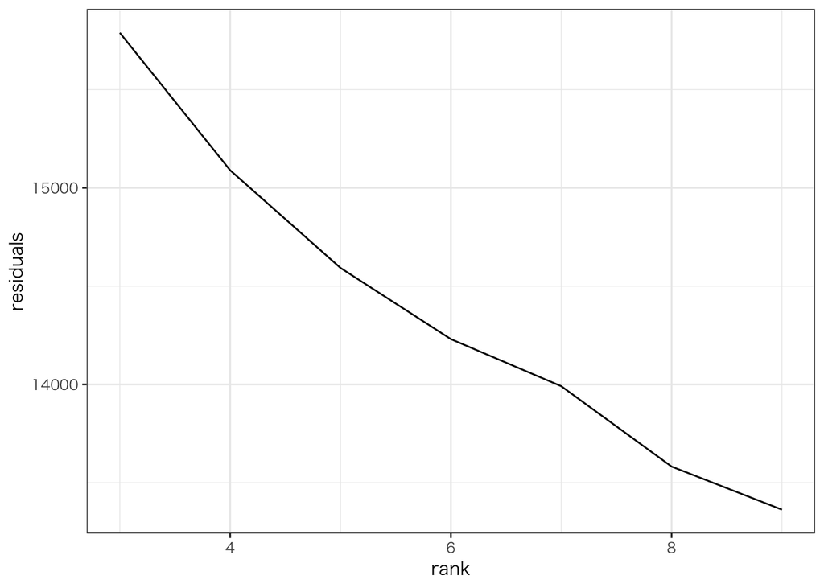

```r
smr %>%
  ggplot(aes(rank, residuals))+
  geom_line()
```

基底ベクトル同士の相関は低くなるはずである． 基底ベクトルの相関係数行列の対角成分以外の成分のうち，その絶対値が最大のものを算出し，基底ベクトルの数との関係を以下にプロットした．  
$k=8$から最大相関係数が跳ね上がっており，適切な$k$は7であると判断できる？？

```r
mic <- sapply(res, function(x) {
  a <- mine(basis(x))$MIC
  diag(a) <- 0
  return( max(abs(a)) )
  })

cor <- sapply(res, function(x) {
  a <- cor(basis(x))
  diag(a) <- 0
  return( max(abs(a)) )
  })
smr <- smr %>%
  mutate(cor =  cor,
         mic = mic)
```

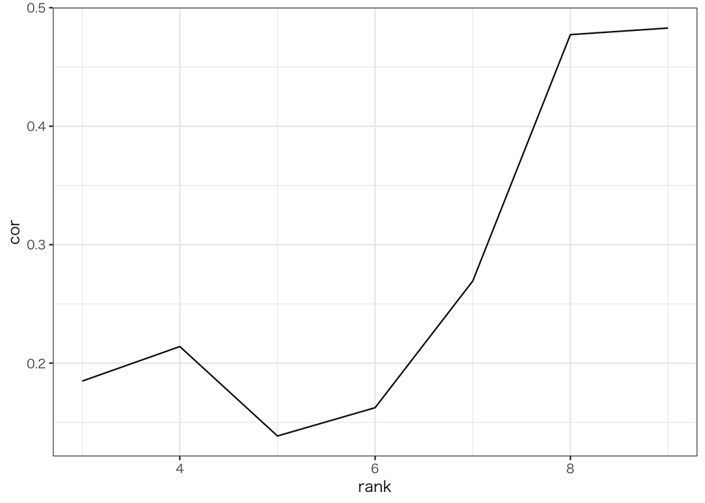

```r
smr %>%
  ggplot(aes(rank, cor))+
  geom_line()
```

続いて，MICでも同様の確認を行った  
こちらではまだまだ行けるような気がする

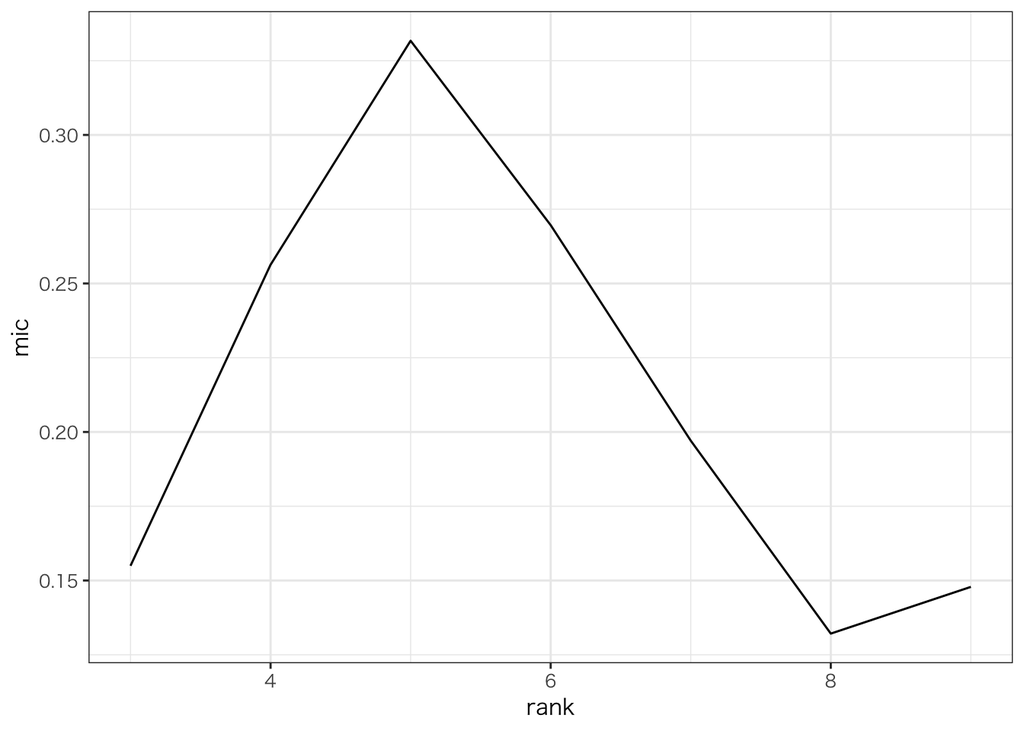

```r
smr %>%
  ggplot(aes(rank, mic))+
  geom_line()
```

```r
pro_mst <- program %>%
  count(station_code, program_code, program_name) %>%
  collect() %>%
  group_by(program_code) %>%
  filter(row_number(desc(n)) == 1) %>%
  mutate(program_name = str_remove_all(program_name, pattern = " "),
         program_name = str_c(station_code, ".", program_name)) %>%
  select(-station_code) %>%
  filter(n != 1)
```

### 6.3.1 基底ベクトル3個

- 流石に3個は少なすぎたか
- なんとなく分かれてそうではある

```r
basis3 <- basis(res[[1]])
basis3 %>%
  as.data.frame() %>%
  rownames_to_column(var = "program_code") %>%
  as_tibble() %>%
  gather(topic, value, -program_code) %>%
  left_join(pro_mst, by = "program_code") %>%
  group_by(topic) %>%
  mutate(rank = row_number(desc(value))) %>%
  filter(rank < 101) %>%
  select( -program_code, -n, -value) %>%
  spread(topic, program_name) %>%
  datatable(class = 'cell-border stripe',
            rownames = FALSE,
            extensions = 'FixedColumns',
            options = list(scrollX = TRUE, scrollCollapse = TRUE
  ))
```

| rank | V1 | V2 | V3 |
| --- | --- | --- | --- |
| 1 | 1.ＺＩＰ！ | 1.ＮＥＷＳ ＺＥＲＯ | 6.ニュースウオッチ９ |
| 2 | 3.めざましテレビ・第２部 | 1.月曜から夜ふかし | 6.ＮＨＫニュースおはよう日本 |
| 3 | 1.ヒルナンデス！ | 4.報道ステーション | 6.ＮＨＫニュース７ |
| 4 | 3.とくダネ！ | 4.雨上がり決死隊のトーク番組アメトーーク！ | 6.ＮＨＫニュースおはよう日本 |
| 5 | 1.スッキリ！！・１部 | 5.ワールドビジネスサテライト | 6.あさイチ |
| 6 | 4.グッド！モーニング・７時台 | 1.Ｇｏｉｎｇ！Ｓｐｏｒｔｓ＆Ｎｅｗｓ | 7.おかあさんといっしょ |
| 7 | 1.ｎｅｗｓ ｅｖｅｒｙ．・第３部 | 2.ＮＥＷＳ２３ | 6.首都圏ネットワーク |
| 8 | 4.羽鳥慎一モーニングショー | 4.マツコ＆有吉かりそめ天国 | 6.ＮＨＫニュースおはよう日本 |
| 9 | 4.グッド！モーニング・６時台 | 3.ユアタイム | 5.Ｎｅｗｓモーニングサテライト２部 |
| 10 | 4.報道ステーション | 3.土曜プレミアム・ＩＰＰＯＮグランプリ | 7.いないいないばあっ！ |

[output cut: 90 more lines]

### 6.3.2 基底ベクトル4個

- 放送局で分かれ始めた？

```r
basis4 <- basis(res[[2]])
basis4 %>%
  as.data.frame() %>%
  rownames_to_column(var = "program_code") %>%
  as_tibble() %>%
  gather(topic, value, -program_code) %>%
  left_join(pro_mst, by = "program_code") %>%
  group_by(topic) %>%
  mutate(rank = row_number(desc(value))) %>%
  filter(rank < 101) %>%
  select( -program_code, -n, -value) %>%
  spread(topic, program_name) %>%
  datatable(class = 'cell-border stripe',
            rownames = FALSE,
            extensions = 'FixedColumns',
            options = list(scrollX = TRUE, scrollCollapse = TRUE
  ))
```

| rank | V1 | V2 | V3 | V4 |
| --- | --- | --- | --- | --- |
| 1 | 1.ＺＩＰ！ | 4.羽鳥慎一モーニングショー | 6.ニュースウオッチ９ | 3.めざましテレビ・第２部 |
| 2 | 1.スッキリ！！・１部 | 4.グッド！モーニング・７時台 | 6.ＮＨＫニュースおはよう日本 | 3.とくダネ！ |
| 3 | 1.ヒルナンデス！ | 4.グッド！モーニング・６時台 | 6.ＮＨＫニュース７ | 1.ＮＥＷＳ ＺＥＲＯ |
| 4 | 7.おかあさんといっしょ | 4.スーパーＪチャンネル | 6.ＮＨＫニュースおはよう日本 | 3.めざましテレビ・第１部 |
| 5 | 7.いないいないばあっ！ | 4.報道ステーション | 6.あさイチ | 3.土曜プレミアム・ＩＰＰＯＮグランプリ |
| 6 | 1.ｎｅｗｓ ｅｖｅｒｙ．・第３部 | 2.ひるおび！・午後 | 6.首都圏ネットワーク | 1.月曜から夜ふかし |
| 7 | 1.スッキリ！！・２部 |  | 6.ＮＨＫニュースおはよう日本 | 4.報道ステーション |
| 8 | 1.情報ライブミヤネ屋 | 2.あさチャン！・第２部 | 6.連続テレビ小説・ひよっこ | 4.雨上がり決死隊のトーク番組アメトーーク！ |
| 9 | 7.みいつけた！ | 2.サンデーモーニング | 6.ＮＨＫニュースおはよう日本・首都圏 | 1.ヒルナンデス！ |
| 10 | 7.おかあさんといっしょ | 2.Ｎスタ・第２部 | 6.連続テレビ小説・わろてんか | 1.世界の果てまでイッテＱ！ |

[output cut: 90 more lines]

### 6.3.3 基底ベクトル5個

- トピック2と4が綺麗に抜けてる
- 子供向けトピックとNHKトピック
- それ以外はよく分からん
- トピック5はテレ朝？

```r
basis5 <- basis(res[[3]])
basis5 %>%
  as.data.frame() %>%
  rownames_to_column(var = "program_code") %>%
  as_tibble() %>%
  gather(topic, value, -program_code) %>%
  left_join(pro_mst, by = "program_code") %>%
  group_by(topic) %>%
  mutate(rank = row_number(desc(value))) %>%
  filter(rank < 101) %>%
  select( -program_code, -n, -value) %>%
  spread(topic, program_name) %>%
  datatable(class = 'cell-border stripe',
            rownames = FALSE,
            extensions = 'FixedColumns',
            options = list(scrollX = TRUE, scrollCollapse = TRUE
  ))
```

| rank | V1 | V2 | V3 | V4 | V5 |
| --- | --- | --- | --- | --- | --- |
| 1 | 1.ＮＥＷＳ ＺＥＲＯ | 7.おかあさんといっしょ | 1.ＺＩＰ！ | 6.ニュースウオッチ９ | 4.羽鳥慎一モーニングショー |
| 2 | 1.月曜から夜ふかし | 7.いないいないばあっ！ | 3.めざましテレビ・第２部 | 6.ＮＨＫニュースおはよう日本 | 4.グッド！モーニング・７時台 |
| 3 | 4.報道ステーション | 7.みいつけた！ | 1.ヒルナンデス！ | 6.ＮＨＫニュース７ | 4.グッド！モーニング・６時台 |
| 4 | 4.雨上がり決死隊のトーク番組アメトーーク！ | 7.おかあさんといっしょ | 3.とくダネ！ | 6.ＮＨＫニュースおはよう日本 | 4.スーパーＪチャンネル |
| 5 | 5.ワールドビジネスサテライト | 7.天才てれびくんＹＯＵ | 1.スッキリ！！・１部 | 6.あさイチ | 4.報道ステーション |
| 6 | 1.Ｇｏｉｎｇ！Ｓｐｏｒｔｓ＆Ｎｅｗｓ | 7.コレナンデ商会 | 1.ｎｅｗｓ ｅｖｅｒｙ．・第３部 | 6.首都圏ネットワーク | 2.ひるおび！・午後 |
| 7 | 1.Ｏｈａ！４ＮＥＷＳ ＬＩＶＥ・第１部 | 7.シャキーン！ | 1.情報ライブミヤネ屋 | 6.ＮＨＫニュースおはよう日本 | 2.あさチャン！・第２部 |
| 8 | 4.マツコ＆有吉かりそめ天国 | 7.みいつけた！ | 1.世界の果てまでイッテＱ！ | 5.Ｎｅｗｓモーニングサテライト２部 | 2.Ｎスタ・第２部 |
| 9 | 2.ＮＥＷＳ２３ | 7.アニメはなかっぱ | 3.バイキング | 6.連続テレビ小説・ひよっこ | 2.サンデーモーニング |
| 10 | 3.ユアタイム | 4.ドラえもん | 1.ＮＥＷＳ ＺＥＲＯ | 6.ＮＨＫニュースおはよう日本・首都圏 | 4.相棒 |

[output cut: 90 more lines]

### 6.3.4 基底ベクトル6個

- 日テレトピック出現（トピック4）
- トピック3はフジテレビか
- トピック1は 人気 & 夜報道 番組という感じ

```r
basis6 <- basis(res[[4]])
basis6 %>%
  as.data.frame() %>%
  rownames_to_column(var = "program_code") %>%
  as_tibble() %>%
  gather(topic, value, -program_code) %>%
  left_join(pro_mst, by = "program_code") %>%
  group_by(topic) %>%
  mutate(rank = row_number(desc(value))) %>%
  filter(rank < 101) %>%
  select( -program_code, -n, -value) %>%
  spread(topic, program_name) %>%
  datatable(class = 'cell-border stripe',
            rownames = FALSE,
            extensions = 'FixedColumns',
            options = list(scrollX = TRUE, scrollCollapse = TRUE
  ))
```

| rank | V1 | V2 | V3 | V4 | V5 | V6 |
| --- | --- | --- | --- | --- | --- | --- |
| 1 | 1.ＮＥＷＳ ＺＥＲＯ | 6.ニュースウオッチ９ | 3.めざましテレビ・第２部 | 1.ＺＩＰ！ | 4.羽鳥慎一モーニングショー | 7.おかあさんといっしょ |
| 2 | 4.報道ステーション | 6.ＮＨＫニュースおはよう日本 | 3.とくダネ！ | 1.ヒルナンデス！ | 4.グッド！モーニング・７時台 | 7.いないいないばあっ！ |
| 3 | 1.月曜から夜ふかし | 6.ＮＨＫニュース７ | 3.バイキング | 1.スッキリ！！・１部 | 4.グッド！モーニング・６時台 | 7.みいつけた！ |
| 4 | 4.雨上がり決死隊のトーク番組アメトーーク！ | 6.ＮＨＫニュースおはよう日本 | 3.めざましテレビ・第１部 | 1.ｎｅｗｓ ｅｖｅｒｙ．・第３部 | 4.スーパーＪチャンネル | 7.おかあさんといっしょ |
| 5 | 5.ワールドビジネスサテライト | 6.あさイチ | 3.ノンストップ！ | 1.世界の果てまでイッテＱ！ | 2.ひるおび！・午後 | 7.天才てれびくんＹＯＵ |
| 6 | 1.Ｇｏｉｎｇ！Ｓｐｏｒｔｓ＆Ｎｅｗｓ | 6.首都圏ネットワーク | 3.ＦＮＮみんなのニュース | 1.情報ライブミヤネ屋 | 4.報道ステーション | 7.コレナンデ商会 |
| 7 | 2.ＮＥＷＳ２３ | 6.ＮＨＫニュースおはよう日本 | 3.めざましどようび |  | 2.あさチャン！・第２部 | 7.シャキーン！ |
| 8 | 4.マツコ＆有吉かりそめ天国 | 5.Ｎｅｗｓモーニングサテライト２部 | 3.みんなのニュース | 1.スッキリ！！・２部 |  | 7.みいつけた！ |
| 9 | 1.Ｏｈａ！４ＮＥＷＳ ＬＩＶＥ・第１部 | 6.連続テレビ小説・ひよっこ | 3.直撃ＬＩＶＥグッディ！ | 1.ＮＥＷＳ ＺＥＲＯ | 4.相棒 | 7.アニメはなかっぱ |
| 10 | 3.ユアタイム | 6.ＮＨＫニュースおはよう日本・首都圏 | 3.直撃ＬＩＶＥグッディ！ | 1.ｎｅｗｓ ｅｖｅｒｙ．・第２部 | 4.ワイド！スクランブル・第１部 | 7.アニメ忍たま乱太郎 |

[output cut: 90 more lines]

### 6.3.5 基底ベクトル7個

```r
basis7 <- basis(res[[5]])
basis7 %>%
  as.data.frame() %>%
  rownames_to_column(var = "program_code") %>%
  as_tibble() %>%
  gather(topic, value, -program_code) %>%
  left_join(pro_mst, by = "program_code") %>%
  group_by(topic) %>%
  mutate(rank = row_number(desc(value))) %>%
  filter(rank < 101) %>%
  select( -program_code, -n, -value) %>%
  spread(topic, program_name) %>%
  datatable(class = 'cell-border stripe',
            rownames = FALSE,
            extensions = 'FixedColumns',
            options = list(scrollX = TRUE, scrollCollapse = TRUE
  ))
```

| rank | V1 | V2 | V3 | V4 | V5 | V6 | V7 |
| --- | --- | --- | --- | --- | --- | --- | --- |
| 1 | 3.めざましテレビ・第２部 | 1.ＺＩＰ！ |  | 1.世界の果てまでイッテＱ！ | 1.ＮＥＷＳ ＺＥＲＯ | 6.ニュースウオッチ９ | 7.おかあさんといっしょ |
| 2 | 3.とくダネ！ | 4.羽鳥慎一モーニングショー | 5.Ｎｅｗｓモーニングサテライト２部 | 4.報道ステーション | 4.報道ステーション | 6.ＮＨＫニュースおはよう日本 | 7.いないいないばあっ！ |
| 3 | 3.バイキング | 4.グッド！モーニング・７時台 |  | 1.ザ！鉄腕！ＤＡＳＨ！！ | 1.月曜から夜ふかし | 6.ＮＨＫニュース７ | 7.みいつけた！ |
| 4 | 3.めざましテレビ・第１部 | 1.スッキリ！！・１部 |  | 2.日曜劇場・９９．９・刑事専門弁護士・ＳＥＡＳＯＮ２ | 5.ワールドビジネスサテライト | 6.ＮＨＫニュースおはよう日本 | 7.おかあさんといっしょ |
| 5 | 1.ヒルナンデス！ | 4.グッド！モーニング・６時台 | 5.おそ松さん | 3.土曜プレミアム・ＩＰＰＯＮグランプリ | 4.雨上がり決死隊のトーク番組アメトーーク！ | 6.あさイチ | 7.天才てれびくんＹＯＵ |
| 6 | 3.ノンストップ！ | 2.ひるおび！・午後 |  |  | 1.Ｇｏｉｎｇ！Ｓｐｏｒｔｓ＆Ｎｅｗｓ | 6.首都圏ネットワーク | 1.ヒルナンデス！ |
| 7 | 3.ＦＮＮみんなのニュース | 4.スーパーＪチャンネル | 5.ドラマブレイク・客主 |  | 2.ＮＥＷＳ２３ | 6.ＮＨＫニュースおはよう日本 | 7.コレナンデ商会 |
| 8 | 3.土曜プレミアム・ＩＰＰＯＮグランプリ | 1.情報ライブミヤネ屋 | 5.斉木楠雄のサイ難 | 1.ＮＥＷＳ ＺＥＲＯ | 4.マツコ＆有吉かりそめ天国 | 6.ＮＨＫニュースおはよう日本・首都圏 | 7.シャキーン！ |
| 9 | 1.ＮＥＷＳ ＺＥＲＯ | 1.ヒルナンデス！ | 5.銀魂． | 2.日曜劇場・陸王 | 1.Ｏｈａ！４ＮＥＷＳ ＬＩＶＥ・第１部 | 6.連続テレビ小説・ひよっこ | 7.みいつけた！ |
| 10 |  | 1.ｎｅｗｓ ｅｖｅｒｙ．・第３部 | 5.ドラマブレイク・奇皇后ふたつの愛涙の誓い | 2.金曜ドラマ・アンナチュラル | 1.ナカイの窓 | 6.ＮＨＫニュースおはよう日本 | 7.アニメはなかっぱ |

[output cut: 90 more lines]

### 6.3.6 基底ベクトル8個

```r
basis8 <- basis(res[[6]])
basis8 %>%
  as.data.frame() %>%
  rownames_to_column(var = "program_code") %>%
  as_tibble() %>%
  gather(topic, value, -program_code) %>%
  left_join(pro_mst, by = "program_code") %>%
  group_by(topic) %>%
  mutate(rank = row_number(desc(value))) %>%
  filter(rank < 101) %>%
  select( -program_code, -n, -value) %>%
  spread(topic, program_name) %>%
  datatable(class = 'cell-border stripe',
            rownames = FALSE,
            extensions = 'FixedColumns',
            options = list(scrollX = TRUE, scrollCollapse = TRUE
  ))
```

| rank | V1 | V2 | V3 | V4 | V5 | V6 | V7 | V8 |
| --- | --- | --- | --- | --- | --- | --- | --- | --- |
| 1 | 6.ニュースウオッチ９ | 7.おかあさんといっしょ | 4.報道ステーション | 3.めざましテレビ・第２部 | 1.ＺＩＰ！ | 1.ＮＥＷＳ ＺＥＲＯ | 4.羽鳥慎一モーニングショー | 4.報道ステーション |
| 2 | 6.ＮＨＫニュースおはよう日本 | 7.いないいないばあっ！ | 2.日曜劇場・９９．９・刑事専門弁護士・ＳＥＡＳＯＮ２ | 3.とくダネ！ | 1.ヒルナンデス！ | 5.ワールドビジネスサテライト | 4.グッド！モーニング・７時台 |  |
| 3 | 6.ＮＨＫニュース７ | 7.みいつけた！ |  | 3.バイキング | 1.スッキリ！！・１部 | 1.月曜から夜ふかし | 4.グッド！モーニング・６時台 | 1.ＮＥＷＳ ＺＥＲＯ |
| 4 | 6.ＮＨＫニュースおはよう日本 | 7.おかあさんといっしょ | 1.世界の果てまでイッテＱ！ | 3.めざましテレビ・第１部 | 1.ｎｅｗｓ ｅｖｅｒｙ．・第３部 | 1.Ｏｈａ！４ＮＥＷＳ ＬＩＶＥ・第１部 | 2.ひるおび！・午後 | 3.土曜プレミアム・ＩＰＰＯＮグランプリ |
| 5 | 6.あさイチ | 7.天才てれびくんＹＯＵ |  | 3.ノンストップ！ | 1.情報ライブミヤネ屋 | 1.Ｇｏｉｎｇ！Ｓｐｏｒｔｓ＆Ｎｅｗｓ | 4.スーパーＪチャンネル | 1.世界の果てまでイッテＱ！ |
| 6 | 6.首都圏ネットワーク | 7.コレナンデ商会 | 2.日曜劇場・陸王 | 3.ＦＮＮみんなのニュース | 1.スッキリ！！・２部 | 4.お願い！ランキング | 4.報道ステーション | 2.マツコの知らない世界 |
| 7 | 6.ＮＨＫニュースおはよう日本 | 7.シャキーン！ | 2.金曜ドラマ・アンナチュラル | 3.直撃ＬＩＶＥグッディ！ | 1.ｎｅｗｓ ｅｖｅｒｙ．・第２部 |  | 2.あさチャン！・第２部 | 4.雨上がり決死隊のトーク番組アメトーーク！ |
| 8 | 5.Ｎｅｗｓモーニングサテライト２部 | 7.みいつけた！ | 3.土曜プレミアム・ＩＰＰＯＮグランプリ | 3.めざましどようび | 1.ＰＯＮ！ | 3.フジバラナイトＦＲＩ・フジヤマふじおし村上マヨこの指と～まれ！次ナルＴＶ貴族探偵 |  | 1.月曜から夜ふかし |
| 9 | 6.ＮＨＫニュースおはよう日本・首都圏 | 7.アニメはなかっぱ |  | 3.みんなのニュース | 1.シューイチ | 4.おはよう！時代劇・暴れん坊将軍 | 4.相棒 | 3.コード・ブルー・ドクターヘリ緊急救命・ＴＨＥ ＴＨＩＲＤ ＳＥＡＳＯＮ |
| 10 | 6.ＮＨＫニュースおはよう日本 | 7.アニメ忍たま乱太郎 | 1.ザ！鉄腕！ＤＡＳＨ！！ | 3.直撃ＬＩＶＥグッディ！ | 1.ｎｅｗｓ ｅｖｅｒｙ．・第１部 | 5.おそ松さん | 4.ワイド！スクランブル・第１部 | 1.行列のできる法律相談所 |

[output cut: 90 more lines]

### 6.3.7 基底ベクトル9個

```r
basis9 <- basis(res[[7]])
basis9 %>%
  as.data.frame() %>%
  rownames_to_column(var = "program_code") %>%
  as_tibble() %>%
  gather(topic, value, -program_code) %>%
  left_join(pro_mst, by = "program_code") %>%
  group_by(topic) %>%
  mutate(rank = row_number(desc(value))) %>%
  filter(rank < 101) %>%
  select( -program_code, -n, -value) %>%
  spread(topic, program_name) %>%
  datatable(class = 'cell-border stripe',
            rownames = FALSE,
            extensions = 'FixedColumns',
            options = list(scrollX = TRUE, scrollCollapse = TRUE)
  )
```

| rank | V1 | V2 | V3 | V4 | V5 | V6 | V7 | V8 | V9 |
| --- | --- | --- | --- | --- | --- | --- | --- | --- | --- |
| 1 | 6.ニュースウオッチ９ | 3.土曜プレミアム・ＩＰＰＯＮグランプリ | 7.おかあさんといっしょ |  | 5.Ｎｅｗｓモーニングサテライト２部 | 3.めざましテレビ・第２部 | 4.羽鳥慎一モーニングショー | 1.ＺＩＰ！ | 4.報道ステーション |
| 2 | 6.ＮＨＫニュースおはよう日本 | 4.報道ステーション | 7.いないいないばあっ！ |  | 5.ワールドビジネスサテライト | 3.とくダネ！ | 4.グッド！モーニング・７時台 | 1.ヒルナンデス！ | 2.日曜劇場・９９．９・刑事専門弁護士・ＳＥＡＳＯＮ２ |
| 3 | 6.ＮＨＫニュース７ | 1.ＮＥＷＳ ＺＥＲＯ | 7.みいつけた！ |  | 1.ＮＥＷＳ ＺＥＲＯ | 3.バイキング | 4.グッド！モーニング・６時台 | 1.スッキリ！！・１部 |  |
| 4 | 6.ＮＨＫニュースおはよう日本 | 1.世界の果てまでイッテＱ！ | 7.おかあさんといっしょ | 5.おそ松さん | 1.Ｏｈａ！４ＮＥＷＳ ＬＩＶＥ・第１部 | 3.めざましテレビ・第１部 | 2.ひるおび！・午後 | 1.ｎｅｗｓ ｅｖｅｒｙ．・第３部 | 1.世界の果てまでイッテＱ！ |
| 5 | 6.あさイチ |  | 7.天才てれびくんＹＯＵ |  | 1.Ｇｏｉｎｇ！Ｓｐｏｒｔｓ＆Ｎｅｗｓ | 3.ノンストップ！ | 4.スーパーＪチャンネル | 1.情報ライブミヤネ屋 | 2.日曜劇場・陸王 |
| 6 | 6.首都圏ネットワーク | 4.雨上がり決死隊のトーク番組アメトーーク！ | 7.コレナンデ商会 | 5.ドラマブレイク・客主 | 1.月曜から夜ふかし | 3.ＦＮＮみんなのニュース | 4.報道ステーション | 1.スッキリ！！・２部 | 2.金曜ドラマ・アンナチュラル |
| 7 | 6.ＮＨＫニュースおはよう日本 | 2.マツコの知らない世界 | 7.シャキーン！ | 5.銀魂． | 4.お願い！ランキング | 3.直撃ＬＩＶＥグッディ！ | 2.あさチャン！・第２部 | 1.ｎｅｗｓ ｅｖｅｒｙ．・第２部 | 3.土曜プレミアム・ＩＰＰＯＮグランプリ |
| 8 | 6.ＮＨＫニュースおはよう日本・首都圏 | 1.月曜から夜ふかし | 7.みいつけた！ | 5.斉木楠雄のサイ難 | 4.報道ステーション | 3.めざましどようび | 4.ワイド！スクランブル・第１部 | 1.ＰＯＮ！ | 1.ザ！鉄腕！ＤＡＳＨ！！ |
| 9 | 6.連続テレビ小説・ひよっこ | 1.行列のできる法律相談所 | 7.アニメはなかっぱ | 5.ドラマブレイク・奇皇后ふたつの愛涙の誓い | 4.おはよう！時代劇・暴れん坊将軍 | 3.みんなのニュース | 4.相棒 | 1.シューイチ | 3.ニチファミ！・逮捕の瞬間！警察２４時 |
| 10 | 6.ＮＨＫニュースおはよう日本 | 3.コード・ブルー・ドクターヘリ緊急救命・ＴＨＥ ＴＨＩＲＤ ＳＥＡＳＯＮ | 7.アニメ忍たま乱太郎 | 5.ドラマブレイク・六龍が飛ぶ | 3.フジバラナイトＦＲＩ・フジヤマふじおし村上マヨこの指と～まれ！次ナルＴＶ貴族探偵 | 3.直撃ＬＩＶＥグッディ！ | 2.ゴゴスマ・ＧＯＧＯ！Ｓｍｉｌｅ！ | 1.ｎｅｗｓ ｅｖｅｒｙ．・第１部 | 4.木曜ドラマ・ＢＧ・身辺警護人 |

[output cut: 90 more lines]

## 6.4 視聴者に注目

$k=7$を例にとり，各トピックに何人の視聴者が属するかを以下に示す  
各視聴者にもっとも寄与する共起パターンを抽出すると解釈できる

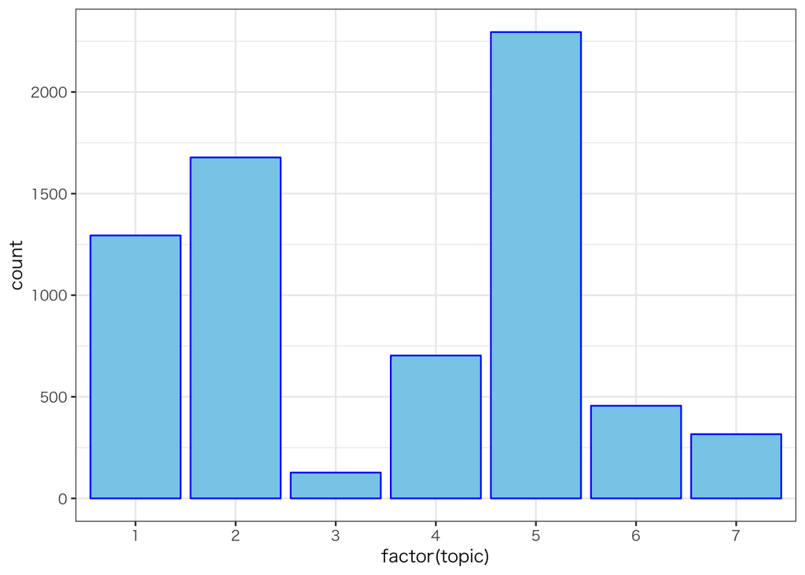

```r
coef(res[[5]]) %>%
  apply(2, function(x) which(x == max(x))) %>%
  tibble(topic = .) %>%
  ggplot(aes(factor(topic)))+
  geom_bar(colour = "blue", fill = "skyblue")
```

推定された係数の散布図をいかに示す．  
スパースなトピックとそうでないトピックがある

- 下三角が散布図
- 対角が各トピックのカーネル密度
- 上三角が2dカーネル密度

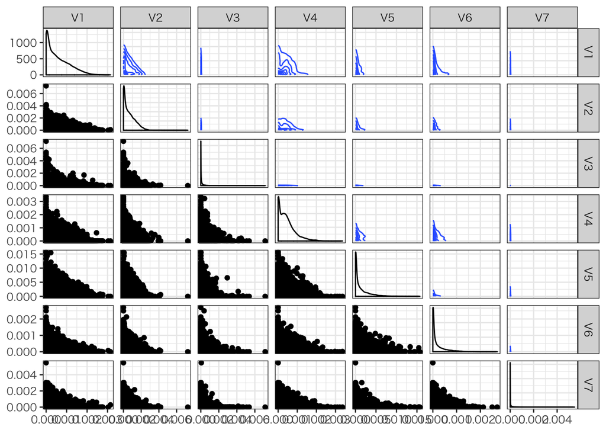

```r
coef(res[[5]]) %>%
  t() %>%
  as_tibble() %>%
  ggpairs(upper = list(continuous = "density", combo = "box_no_facet"))
```

## 6.5 テレビ局に注目

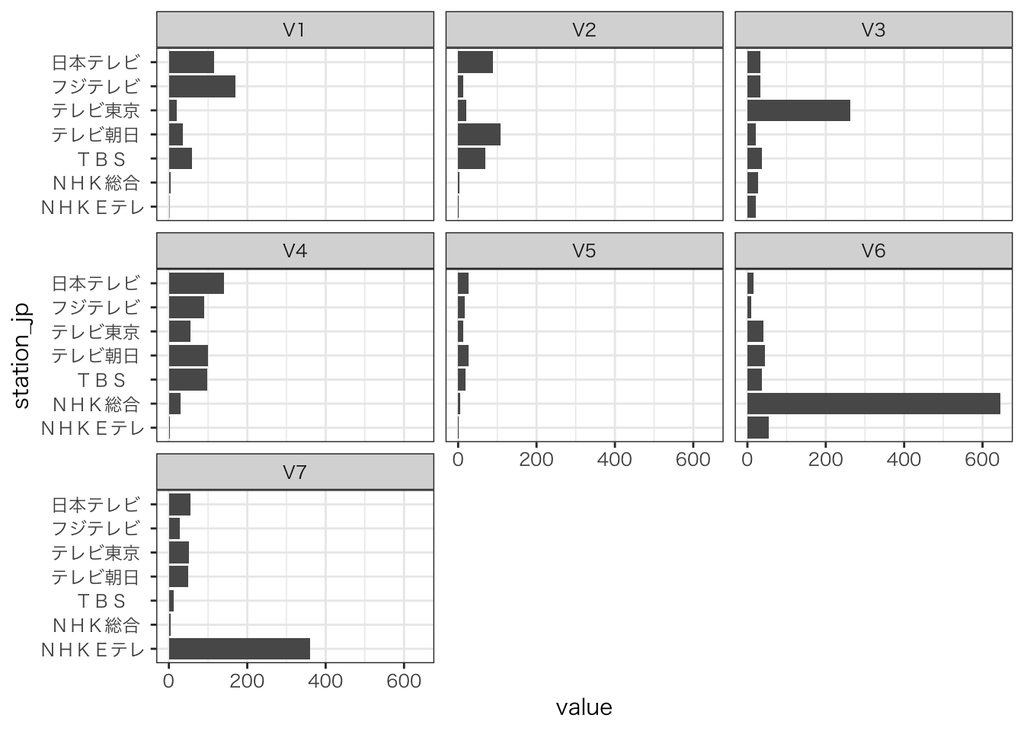

```r
basis(res[[5]]) %>%
  as.data.frame() %>%
  rownames_to_column(var = "program_code") %>%
  as_tibble() %>%
  left_join(collect(distinct(program, station_code, program_code)),
            by = "program_code") %>%
  gather(topic, value, -program_code, -station_code) %>%
  group_by(station_code, topic) %>%
  summarise(value = sum(value)) %>%
  left_join(collect(sta), by = "station_code") %>%
  ggplot(aes(station_jp, value))+
  geom_bar(stat="identity")+
  facet_wrap(~topic)+
  coord_flip()
```

## 6.6 番組分類に注目

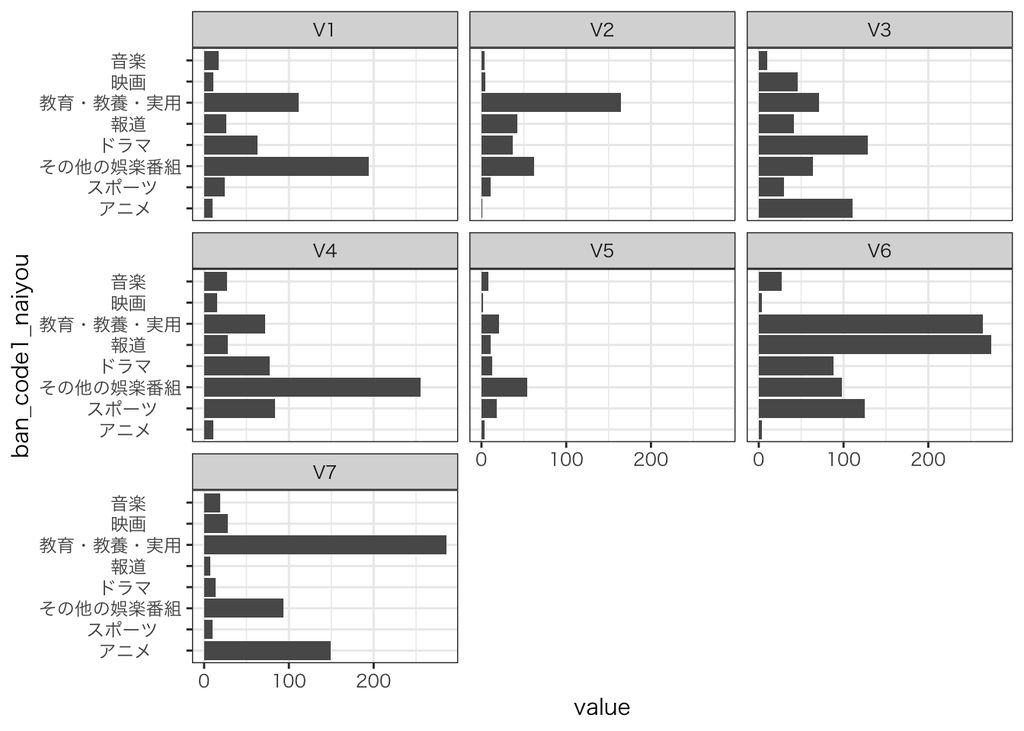

```r
basis(res[[5]]) %>%
  as.data.frame() %>%
  rownames_to_column(var = "program_code") %>%
  as_tibble() %>%
  left_join(collect(distinct(program, ban_code1, program_code)),
            by = "program_code") %>%
  gather(topic, value, -program_code, -ban_code1) %>%
  group_by(ban_code1, topic) %>%
  summarise(value = sum(value)) %>%
  left_join(collect(ban1), by = "ban_code1") %>%
  ggplot(aes(ban_code1_naiyou, value))+
  geom_bar(stat="identity")+
  facet_wrap(~topic)+
  coord_flip()
```

## 6.7 中分類に注目

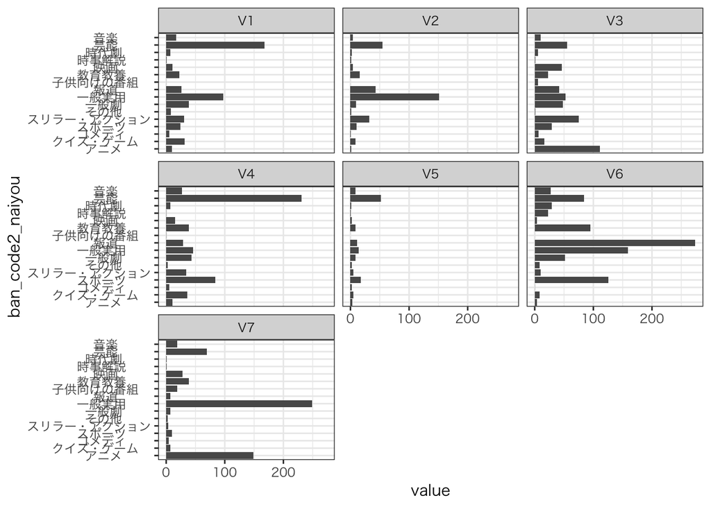

```r
basis(res[[5]]) %>%
  as.data.frame() %>%
  rownames_to_column(var = "program_code") %>%
  as_tibble() %>%
  left_join(collect(distinct(program, ban_code2, program_code)),
            by = "program_code") %>%
  gather(topic, value, -program_code, -ban_code2) %>%
  group_by(ban_code2, topic) %>%
  summarise(value = sum(value)) %>%
  left_join(collect(ban2), by = "ban_code2") %>%
  ggplot(aes(ban_code2_naiyou, value))+
  geom_bar(stat="identity")+
  facet_wrap(~topic)+
  coord_flip()
```

## 6.8 VRクラスタに注目

図を作りたかっただけ

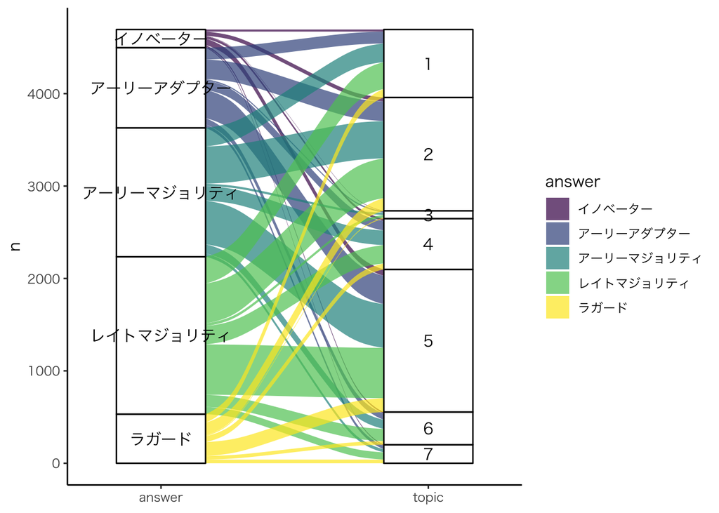

```r
innov <- prof %>%
  filter(qu_genre_code == 25, question_code == 4) %>%
  select(house_num, answer, answer_code) %>%
  collect() %>%
  mutate(answer = str_remove_all(answer, pattern = " "))

coef7 <- coef(res[[5]])
apply(coef7, 2, function(x) which(x == max(x)) ) %>%
  data.frame(topic = .) %>%
  rownames_to_column(var = "house_num") %>%
  as_tibble() %>%
  mutate(house_num = as.integer(house_num)) %>%
  left_join(innov, by = "house_num") %>%
  drop_na(answer) %>%
  mutate(answer = fct_reorder(answer, answer_code)) %>%
  count(topic, answer) %>%

  ggplot(aes(axis1 = answer, axis2 = topic, y = n)) +
  scale_x_discrete(limits = c("answer", "topic"), expand = c(.1, .05)) +
  geom_alluvium(aes(fill = answer), alpha=.7)+
  scale_fill_viridis_d()+
  geom_stratum()+
  geom_text(stat = "stratum", label.strata = TRUE, family = "HiraKakuPro-W3")+
  theme_classic(base_family = "HiraKakuPro-W3")
```

# 7 考察・まとめ

## 7.1 まとめ

- テレビ視聴におけるTF-IDFを定義して，NMFした

## 7.2 考察

- 特にない
- 報道番組の傾向が強い
- 報道番組は別でやったほうが良いかも
- もしくは，TF-IDFの定義が良くないか

## 7.3 感想

- 最近テキストマイニング興味あって，**やってみたかっただけ**
- 正直，テレビをあまり見ないので**ドメイン知識がない**
- 結果の解釈が難しくて，**何か気づいたら教えていただきたい**
- 基底ベクトル数10~15は今計算中